[O’Hara on GitHub](https://github.com/oharac)

# Plot species impact expansion

Compiled on Tue Jun 23 09:17:19 2020 by ohara

```r
knitr::opts_chunk$set(fig.width = 6, fig.height = 4, fig.path = 'figs/',
                      echo = TRUE, message = FALSE, warning = FALSE)

library(raster)
library(sf)
source('https://raw.githubusercontent.com/oharac/src/master/R/common.R')

source(here('common_fxns.R'))
```

# 1 Summary

Here we plot species impact expansion - how impacted range area is changing over time. We can look at this on a stressor-by-stressor basis, and grouped by cumulative stressors by category.

## 1.1 Methods summary

Read in all the impact summaries. Attach taxonomic information and range information.

For each stressor, calculate impact expansion by taxon, by range size, and overall.

- Impact expansion will be change in percent impacted range?
- or absolute? This devalues small-ranged species. Perhaps in the range size calculations.

# 2 Methods

## 2.1 Get impact summaries

Load the impact summaries, attach info on taxonomic groupings and range quintiles.

```r
imp_range_file <- file.path(here('int/impacted_ranges.csv'))

if(!file.exists(imp_range_file)) {
  # unlink(imp_range_file)
  spp_incl <- get_incl_spp() %>%
    filter(!is.na(stressor)) %>%
    select(-code) %>%
    distinct()

  spp_impact_fstem <- file.path(dir_bd_anx, 'spp_impacts/spp_impacts_%s_%s.csv')
  spp_ids <- spp_incl$iucn_sid %>% unique() %>% sort()
  str_cats <- c('all', 'climate', 'fishing', 'land-based', 'ocean')

  impacts_list <- parallel::mclapply(spp_ids,
      FUN = function(id) { ### id <- spp_ids[1]
        message('processing spp ', id)
        tmp_list<- lapply(str_cats, FUN = function(str_cat) {
          ### str_cat <- 'all'
          f <- sprintf(spp_impact_fstem, id, str_cat)
          x <- read_csv(f) %>%
            mutate(impacts = str_replace_all(basename(f), '.+[0-9]+_|.csv', ''))
          return(x)
        })
        tmp_df <- bind_rows(tmp_list)
        return(tmp_df)
      }, mc.cores = 40)

  imp_range_df <- bind_rows(impacts_list) %>%
    mutate(stressor = ifelse(stressor == 'cumulative',
                             paste0('cum_', impacts), stressor)) %>%
    select(-impacts) %>%
    filter(iucn_sid %in% spp_incl$iucn_sid) %>%
    distinct() %>%
    mutate(pct_impact = impact_km2 / range_km2)

  write_csv(imp_range_df, imp_range_file)
} else {
  imp_range_df <- read_csv(imp_range_file)
}
```

## 2.2 Summarize by stressor

Note, expansion is based only on the species with reported sensitivity - i.e. non-sensitive species are dropped. More conservative perhaps would be to include these species as having constant zero-impact ranges.

### 2.2.1 Stressor on all impacted spp

```r
### utility function to trim a data frame of lm summaries to
### just those with a given p value.  Also rounds results for display.

dt_clean <- function(df) {
  DT::datatable(df %>%
                mutate_if(is.double, round, digits = 5))
}
```

```r
tr_by_stressor_all <- imp_range_df %>%
  filter(!is.na(year)) %>%
  group_by(stressor) %>%
  do(mdl = lm(pct_impact ~ year, data = .)) %>%
  mutate(adj_r2 = summary(mdl)$adj.r.squared) %>%
  broom::tidy(mdl)

dt_clean(tr_by_stressor_all)
```

### 2.2.2 Stressor on impacted spp by range quintile

```r
tr_by_stressorXrange <- imp_range_df %>%
  filter(!is.na(year)) %>%
  mutate(qtile = as.character(qtile)) %>%
    ### broom::tidy doesn't like factors?
    ### https://github.com/tidymodels/broom/issues/796#issuecomment-613378714
  group_by(stressor, qtile) %>%
  do(mdl = lm(pct_impact ~ year, data = .)) %>%
  mutate(adj_r2 = summary(mdl)$adj.r.squared) %>%
  broom::tidy(mdl)

dt_clean(tr_by_stressorXrange)
```

### 2.2.3 Stressor on impacted spp by taxonomic group

```r
message('calculating expansion by taxon')

tr_by_stressorXtaxon <- imp_range_df %>%
  filter(!is.na(year)) %>%
  group_by(stressor, taxon) %>%
  do(mdl = lm(pct_impact ~ year, data = .)) %>%
  mutate(adj_r2 = summary(mdl)$adj.r.squared) %>%
  broom::tidy(mdl)

dt_clean(tr_by_stressorXtaxon)
```

## 2.3 Plot expansion by taxonomic group

```r
imp_range_df <- read_csv(imp_range_file)

spp_expansion_trend_file <- here('int/spp_expansion_trends.csv')
# unlink(spp_expansion_trend_file)

if(!file.exists(spp_expansion_trend_file)) {
  trend_df <- imp_range_df %>%
    group_by(stressor, iucn_sid) %>%
    filter(n_distinct(pct_impact, na.rm = TRUE) > 1) %>%
    do(mdl = lm(pct_impact ~ year, data = .)) %>%
    broom::tidy(mdl) %>%
    filter(term == 'year')

  write_csv(trend_df, spp_expansion_trend_file)
}
```

Use trends to predict species impacted range in 2030.

```r
trend_df <- read_csv(spp_expansion_trend_file)

imp_2030_df <- imp_range_df %>%
  left_join(trend_df, by = c('iucn_sid', 'stressor')) %>%
  filter(year == 2013) %>%
  mutate(estimate = ifelse(is.na(estimate), 0, estimate),
         pct_impact = pct_impact + (2030 - 2013) * estimate,
         pct_impact = case_when(pct_impact < 0 ~ 0,
                                pct_impact > 1 ~ 1,
                                TRUE           ~ pct_impact),
         year = 2030) %>%
  select(iucn_sid, year, pct_impact, stressor) %>%
  bind_rows(imp_range_df) %>%
  filter(!is.na(pct_impact))
```

```r
rank_df <- read_csv(here('int/spp_ranks.csv'))

range_summary_all <- imp_2030_df %>%
  left_join(rank_df, by = 'iucn_sid') %>%
  group_by(stressor, year) %>%
  summarize(mean_pct_imp = mean(pct_impact),
            sd_pct_imp   = sd(pct_impact))

range_summary_taxon <- imp_2030_df %>%
  left_join(rank_df, by = 'iucn_sid') %>%
  group_by(rank, stressor, year) %>%
  summarize(mean_pct_imp = mean(pct_impact),
            sd_pct_imp   = sd(pct_impact)) %>%
  ungroup()
```

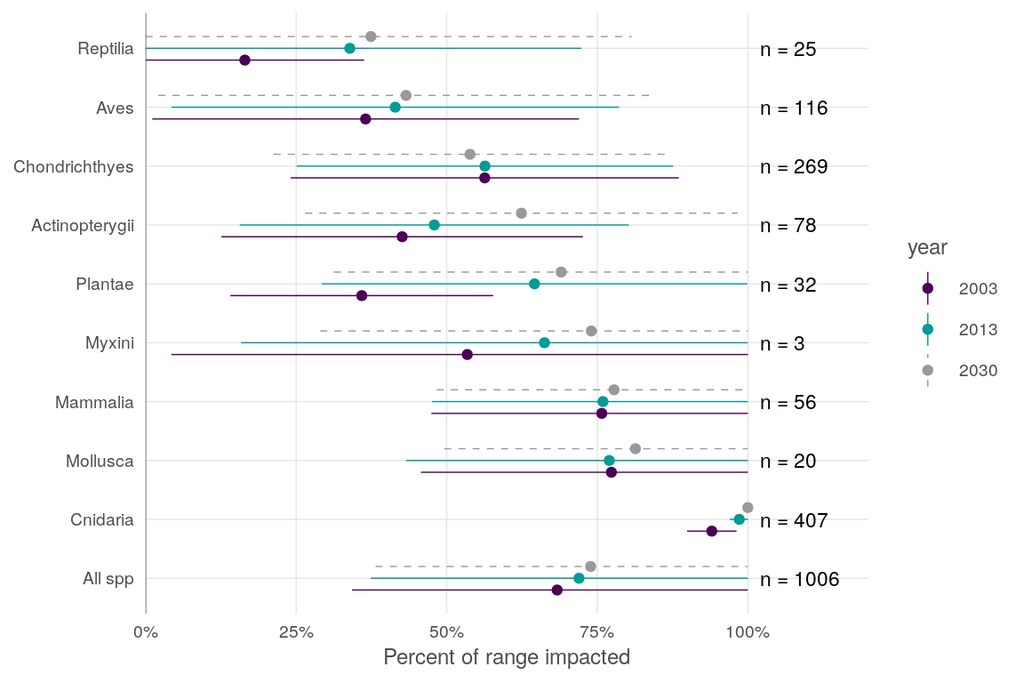

```r
cum_impact_df <- range_summary_all %>%
  filter(stressor == 'cum_all') %>%
  mutate(rank = 'All spp') %>%
  bind_rows(range_summary_taxon %>%
              filter(stressor == 'cum_all') %>%
              arrange(desc(year), desc(mean_pct_imp))) %>%
  filter(year %in% c(2003, 2013, 2030)) %>%
  mutate(rank = fct_inorder(rank),
         year = factor(year)) %>%
  rowwise() %>%
  mutate(ymin = max(0, mean_pct_imp - sd_pct_imp),
         ymax = min(1, mean_pct_imp + sd_pct_imp)) %>%
  ungroup()

n_labels <- read_csv(here('int/spp_count_by_taxon_stressor.csv')) %>%
  filter(stressor == 'cum_all') %>%
  mutate(n_lbl = paste0('n = ', n_spp))

ggplot(cum_impact_df) +
  ggtheme_plot() +
  geom_point(aes(y = mean_pct_imp, x = rank,
                 color = year, group = year),
             position = position_dodge(width = .6)) +
  geom_linerange(aes(x = rank, ymin = ymin, ymax = ymax,
                     color = year, linetype = year, group = year),
             position = position_dodge(width = .6),
             size = .25) +
  geom_hline(yintercept = 0, color = 'grey30', size = .25) +
  geom_text(data = n_labels,
            aes(x = rank, label = n_lbl), y = 1.02,
            size = 3, hjust = 0) +
  scale_color_manual(values = c(hcl.colors(n = 3)[1:2], 'grey60')) +
  scale_linetype_manual(values = c('solid', 'solid', 'dashed')) +
  scale_y_continuous(expand = c(0, 0),
                     limits = c(0, 1.2),
                     breaks = seq(0, 1, .25),
                     labels = paste0(seq(0, 100, 25), '%')) +
  labs(y = 'Percent of range impacted') +
  coord_flip() +
  theme(axis.title.y = element_blank())
```